# Exercise_12_Housing_Data_NoskyChristopher

Nosky, Christopher

1/31/2021

```r
knitr::opts_chunk$set(echo = TRUE)

setwd('C:/Users/cwnos/Documents/DSC520/Git repo/DSC520/dsc520')

library(readxl)
library(Rcmdr)
```

```r
library(ggplot2)
library(pastecs)
library(MASS, pos = 18)
library(car)
week_7_housing <- read_excel("data/week-6-housing.xlsx")

week_7_housing_orginial <- read_excel("data/week-6-housing.xlsx")

week_7_housing <- within(week_7_housing, {
  addr_full <- NULL
  building_grade <- NULL
  ctyname <- NULL
  lat <- NULL
  lon <- NULL
  sale_instrument <- NULL
  sale_reason <- NULL
  sale_warning <- NULL
  sitetype <- NULL
  year_renovated <- NULL
})

week_7_housing_Updated <- na.omit(week_7_housing)
sale_price <- week_7_housing_Updated$`Sale Price`
bathrooms <- subset(week_7_housing_Updated,
                    select = c('bath_full_count', 'bath_half_count',
                               'bath_3qtr_count'), drop = FALSE)

total_bathrooms <- (bathrooms$bath_full_count * 1) +
                   (bathrooms$bath_half_count * 0.5) +
                   (bathrooms$bath_3qtr_count * 0.75)

week_7_housing_Updated$total_bathrooms <- total_bathrooms

week_7_housing_Updated <- subset(week_7_housing_Updated,
                  select = c('Sale Price',
                             'square_feet_total_living',
                             'bedrooms',
                             'sq_ft_lot',
                             'total_bathrooms'))

str(week_7_housing_Updated)
```

```
## tibble [12,865 x 5] (S3: tbl_df/tbl/data.frame)
##  $ Sale Price              : num [1:12865] 698000 649990 572500 420000 369900 ...
##  $ square_feet_total_living: num [1:12865] 2810 2880 2770 1620 1440 4160 3960 3720 4160 2760 ...
##  $ bedrooms                : num [1:12865] 4 4 4 3 3 4 5 4 4 4 ...
##  $ sq_ft_lot               : num [1:12865] 6635 5570 8444 9600 7526 ...
##  $ total_bathrooms         : num [1:12865] 2.5 2.75 2.25 1.75 1.75 3.25 3.75 2.5 3.25 1.75 ...
```

> Work individually on this assignment. You are encouraged to collaborate on ideas and strategies pertinent to this assignment. Data for this assignment is focused on real estate transactions recorded from 1964 to 2016 and can be found in Week 6 Housing.xlsx. Using your skills in statistical correlation, multiple regression and R programming, you are interested in the following variables: Sale Price and several other possible predictors.

> Using your ‘clean’ data set from the previous week complete the following:

> Explain why you chose to remove data from your data set.
> - Starting with the removed data points outlined in Tech Fort this week, I considered each point and came to the same conclusions indicated and removed them from the start.
> - As indicated I also reworked the three(3) separate bathroom variables into a single value, without knowing for certain I was using the same methodology this proved to be an amusing endeavor first arriving at a sum of all the bathroom values for the entire data set. After adding the `total_bathrooms` subset back into `week_7_housing_Updated` I created a new subset `week_7_housing_Updated` with 5 variables.
> - The final variable I removed was **building_grade** because after considering what those values might indicate it opened up a ‘rabbit-hole’ of questions I wasn’t certain I could get the answers for. For example, the biggest question I had after considering that it was a ranking metric for the quality of the build I now question how the ranking might be normalized considering the range of the data set. Given that building code is updated regularly and construction methods and materials are often improved year after year, are we ranking the building_grade based on the year it was built or did we base it off of current standards? If we were to know which method was used to get the ranking we could possibly through a bit of work write a function that normalizes the metric around a single standard.

> Create two variables; one that will contain the variables Sale Price and Square Foot of Lot (same variables used from previous assignment on simple regression) and one that will contain Sale Price and several additional predictors of your choice. Explain the basis for your additional predictor selections.

```r
RegModel.1 <- lm(sale_price~square_feet_total_living, data = week_7_housing_Updated)
```

```r
RegModel.2 <- lm(sale_price~square_feet_total_living+total_bathrooms +bedrooms+sq_ft_lot,
  data = week_7_housing_Updated)
```

> Execute a summary() function on two variables defined in the previous step to compare the model results. What are the R2 and Adjusted R2 statistics? Explain what these results tell you about the overall model. Did the inclusion of the additional predictors help explain any large variations found in Sale Price?

```r
summary(RegModel.1)
```

```
##
## Call:
## lm(formula = sale_price ~ square_feet_total_living, data = week_7_housing_Updated)
##
## Residuals:
##      Min       1Q   Median       3Q      Max
## -1800136  -120257   -41547    44028  3811745
##
## Coefficients:
##                           Estimate Std. Error t value Pr(>|t|)
## (Intercept)              1.891e+05  8.745e+03   21.62   <2e-16 ***
## square_feet_total_living 1.857e+02  3.208e+00   57.88   <2e-16 ***
## ---
## Signif. codes:  0 '***' 0.001 '**' 0.01 '*' 0.05 '.' 0.1 ' ' 1
##
## Residual standard error: 360200 on 12863 degrees of freedom
## Multiple R-squared:  0.2066, Adjusted R-squared:  0.2066
## F-statistic:  3351 on 1 and 12863 DF,  p-value: < 2.2e-16
```

```r
summary(RegModel.2)
```

```
##
## Call:
## lm(formula = sale_price ~ square_feet_total_living + total_bathrooms +
##     bedrooms + sq_ft_lot, data = week_7_housing_Updated)
##
## Residuals:
##      Min       1Q   Median       3Q      Max
## -1975012  -117703   -40353    44570  3787149
##
## Coefficients:
##                            Estimate Std. Error t value Pr(>|t|)
## (Intercept)               2.158e+05  1.451e+04  14.869  < 2e-16 ***
## square_feet_total_living  1.828e+02  5.268e+00  34.698  < 2e-16 ***
## total_bathrooms           2.979e+04  6.969e+03   4.275 1.92e-05 ***
## bedrooms                 -2.734e+04  4.506e+03  -6.068 1.33e-09 ***
## sq_ft_lot                 9.441e-02  5.800e-02   1.628    0.104
## ---
## Signif. codes:  0 '***' 0.001 '**' 0.01 '*' 0.05 '.' 0.1 ' ' 1
##
## Residual standard error: 359500 on 12860 degrees of freedom
## Multiple R-squared:  0.2098, Adjusted R-squared:  0.2096
## F-statistic: 853.6 on 4 and 12860 DF,  p-value: < 2.2e-16
```

> Considering the parameters of the multiple regression model you have created. What are the standardized betas for each parameter and what do the values indicate?

```r
compareCoefs(RegModel.1, RegModel.2)
```

```
## Calls:
## 1: lm(formula = sale_price ~ square_feet_total_living, data =
##   week_7_housing_Updated)
## 2: lm(formula = sale_price ~ square_feet_total_living + total_bathrooms +
##   bedrooms + sq_ft_lot, data = week_7_housing_Updated)
##
##                          Model 1 Model 2
## (Intercept)               189107  215765
## SE                          8745   14511
##
## square_feet_total_living  185.72  182.80
## SE                          3.21    5.27
##
## total_bathrooms                    29793
## SE                                  6969
##
## bedrooms                          -27340
## SE                                  4506
##
## sq_ft_lot                         0.0944
## SE                                0.0580
##
```

> Calculate the confidence intervals for the parameters in your model and explain what the results indicate.

```r
confint.lm(RegModel.1, level = 0.95)
```

```
##                                2.5 %      97.5 %
## (Intercept)              171965.2516 206247.8664
## square_feet_total_living    179.4286    192.0067
```

```r
confint.lm(RegModel.2, level = 0.95)
```

```
##                                  2.5 %        97.5 %
## (Intercept)               1.873207e+05  2.442088e+05
## square_feet_total_living  1.724756e+02  1.931291e+02
## total_bathrooms           1.613289e+04  4.345214e+04
## bedrooms                 -3.617257e+04 -1.850824e+04
## sq_ft_lot                -1.927802e-02  2.081036e-01
```

> Assess the improvement of the new model compared to your original model (simple regression model) by testing whether this change is significant by performing an analysis of variance.

```r
anova(RegModel.1, RegModel.2)
```

```
## Analysis of Variance Table
##
## Model 1: sale_price ~ square_feet_total_living
## Model 2: sale_price ~ square_feet_total_living + total_bathrooms + bedrooms +
##     sq_ft_lot
##   Res.Df        RSS Df  Sum of Sq      F    Pr(>F)
## 1  12863 1.6689e+15
## 2  12860 1.6622e+15  3 6.6248e+12 17.084 4.538e-11 ***
## ---
## Signif. codes:  0 '***' 0.001 '**' 0.01 '*' 0.05 '.' 0.1 ' ' 1
```

> - Based on our reading, I interpret these tables to indicate that both `RegModel.2` significantly improved the fit over `RegModel.1`. As I discussed in my Discussion post last week what we’re looking at here are the F-ratio and the p value to arrive at this conclusion.

> Perform casewise diagnostics to identify outliers and/or influential cases, storing each function’s output in a dataframe assigned to a unique variable name.

```r
RegModelOrg <-
  lm(sale_price~square_feet_total_living+total_bathrooms+bedrooms+building_grade+lat+lon+present_use+sale_instrument+sale_reason+sq_ft_lot+year_built+year_renovated+zip5,
   data=week_7_housing_orginial)
summary(RegModelOrg)
```

```
##
## Call:
## lm(formula = sale_price ~ square_feet_total_living + total_bathrooms +
##     bedrooms + building_grade + lat + lon + present_use + sale_instrument +
##     sale_reason + sq_ft_lot + year_built + year_renovated + zip5,
##     data = week_7_housing_orginial)
##
## Residuals:
##      Min       1Q   Median       3Q      Max
## -2289747  -120423   -44170    41409  3695867
##
## Coefficients:
##                            Estimate Std. Error t value Pr(>|t|)
## (Intercept)              -4.034e+08  1.994e+08  -2.023   0.0431 *
## square_feet_total_living  1.462e+02  6.481e+00  22.562  < 2e-16 ***
## total_bathrooms          -5.018e+03  7.211e+03  -0.696   0.4865
## bedrooms                 -1.109e+04  4.900e+03  -2.264   0.0236 *
## building_grade            2.851e+04  4.487e+03   6.354 2.17e-10 ***
## lat                      -3.033e+04  1.392e+05  -0.218   0.8276
## lon                      -3.316e+05  7.561e+04  -4.385 1.17e-05 ***
## present_use              -7.608e+02  1.048e+02  -7.258 4.15e-13 ***
## sale_instrument           1.506e+02  1.038e+03   0.145   0.8846
## sale_reason              -1.163e+04  1.281e+03  -9.080  < 2e-16 ***
## sq_ft_lot                 3.966e-01  6.120e-02   6.481 9.47e-11 ***
## year_built                3.265e+03  2.625e+02  12.436  < 2e-16 ***
## year_renovated            8.348e+01  1.429e+01   5.844 5.23e-09 ***
## zip5                      3.651e+03  1.995e+03   1.830   0.0672 .
## ---
## Signif. codes:  0 '***' 0.001 '**' 0.01 '*' 0.05 '.' 0.1 ' ' 1
##
## Residual standard error: 353700 on 12851 degrees of freedom
## Multiple R-squared:  0.2356, Adjusted R-squared:  0.2348
## F-statistic: 304.6 on 13 and 12851 DF,  p-value: < 2.2e-16
```

```r
outlierTest(RegModelOrg)
```

```
##       rstudent unadjusted p-value Bonferroni p
## 11992 10.52023         8.8719e-26   1.1414e-21
## 6430  10.46022         1.6653e-25   2.1424e-21
## 6438  10.42325         2.4505e-25   3.1526e-21
## 6437  10.41869         2.5698e-25   3.3060e-21
## 6431  10.31333         7.6660e-25   9.8623e-21
## 6436  10.28181         1.0609e-24   1.3648e-20
## 6441  10.24501         1.5485e-24   1.9922e-20
## 6432  10.20397         2.3570e-24   3.0323e-20
## 6433  10.17790         3.0754e-24   3.9565e-20
## 6442  10.16690         3.4402e-24   4.4258e-20
```

```r
outlierTest(RegModel.1)
```

```
##       rstudent unadjusted p-value Bonferroni p
## 11992 10.62908         2.8052e-26   3.6089e-22
## 4649  10.49256         1.1864e-25   1.5263e-21
## 6438  10.42218         2.4775e-25   3.1873e-21
## 6430  10.41696         2.6161e-25   3.3656e-21
## 6437  10.36474         4.5024e-25   5.7923e-21
## 6431  10.26036         1.3225e-24   1.7014e-20
## 6436  10.22905         1.8232e-24   2.3455e-20
## 6441  10.15082         4.0508e-24   5.2113e-20
## 6432  10.12475         5.2784e-24   6.7907e-20
## 6442  10.07261         8.9440e-24   1.1506e-19
```

```r
outlierTest(RegModel.2)
```

```
##       rstudent unadjusted p-value Bonferroni p
## 11992 10.60351         3.6804e-26   4.7348e-22
## 6430  10.47895         1.3685e-25   1.7606e-21
## 6437  10.42752         2.3434e-25   3.0148e-21
## 4649  10.42102         2.5076e-25   3.2260e-21
## 6438  10.40716         2.8973e-25   3.7274e-21
## 6431  10.32415         6.8549e-25   8.8188e-21
## 6436  10.29126         9.6244e-25   1.2382e-20
## 6433  10.17133         3.2878e-24   4.2297e-20
## 6434  10.17131         3.2886e-24   4.2308e-20
## 6432  10.16850         3.3841e-24   4.3537e-20
```

```r
Out_L_week_7_housing_orginial <- week_7_housing_orginial
```

```r
str(Out_L_week_7_housing_orginial)
```

```
## tibble [12,865 x 24] (S3: tbl_df/tbl/data.frame)
##  $ Sale Date               : POSIXct[1:12865], format: "2006-01-03" "2006-01-03" ...
##  $ Sale Price              : num [1:12865] 698000 649990 572500 420000 369900 ...
##  $ sale_reason             : num [1:12865] 1 1 1 1 1 1 1 1 1 1 ...
##  $ sale_instrument         : num [1:12865] 3 3 3 3 3 15 3 3 3 3 ...
##  $ sale_warning            : chr [1:12865] NA NA NA NA ...
##  $ sitetype                : chr [1:12865] "R1" "R1" "R1" "R1" ...
##  $ addr_full               : chr [1:12865] "17021 NE 113TH CT" "11927 178TH PL NE" "13315 174TH AVE NE" "3303 178TH AVE NE" ...
##  $ zip5                    : num [1:12865] 98052 98052 98052 98052 98052 ...
##  $ ctyname                 : chr [1:12865] "REDMOND" "REDMOND" NA "REDMOND" ...
##  $ postalctyn              : chr [1:12865] "REDMOND" "REDMOND" "REDMOND" "REDMOND" ...
##  $ lon                     : num [1:12865] -122 -122 -122 -122 -122 ...
##  $ lat                     : num [1:12865] 47.7 47.7 47.7 47.6 47.7 ...
##  $ building_grade          : num [1:12865] 9 9 8 8 7 7 10 10 9 8 ...
##  $ square_feet_total_living: num [1:12865] 2810 2880 2770 1620 1440 4160 3960 3720 4160 2760 ...
##  $ bedrooms                : num [1:12865] 4 4 4 3 3 4 5 4 4 4 ...
##  $ bath_full_count         : num [1:12865] 2 2 1 1 1 2 3 2 2 1 ...
##  $ bath_half_count         : num [1:12865] 1 0 1 0 0 1 0 1 1 0 ...
##  $ bath_3qtr_count         : num [1:12865] 0 1 1 1 1 1 1 0 1 1 ...
##  $ year_built              : num [1:12865] 2003 2006 1987 1968 1980 ...
##  $ year_renovated          : num [1:12865] 0 0 0 0 0 0 0 0 0 0 ...
##  $ current_zoning          : chr [1:12865] "R4" "R4" "R6" "R4" ...
##  $ sq_ft_lot               : num [1:12865] 6635 5570 8444 9600 7526 ...
##  $ prop_type               : chr [1:12865] "R" "R" "R" "R" ...
##  $ present_use             : num [1:12865] 2 2 2 2 2 2 2 2 2 2 ...
```

```r
Out_L_week_7_housing_updated <- week_7_housing_Updated
```

```r
str(Out_L_week_7_housing_updated)
```

```
## tibble [12,865 x 5] (S3: tbl_df/tbl/data.frame)
##  $ Sale Price              : num [1:12865] 698000 649990 572500 420000 369900 ...
##  $ square_feet_total_living: num [1:12865] 2810 2880 2770 1620 1440 4160 3960 3720 4160 2760 ...
##  $ bedrooms                : num [1:12865] 4 4 4 3 3 4 5 4 4 4 ...
##  $ sq_ft_lot               : num [1:12865] 6635 5570 8444 9600 7526 ...
##  $ total_bathrooms         : num [1:12865] 2.5 2.75 2.25 1.75 1.75 3.25 3.75 2.5 3.25 1.75 ...
```

```r
RegModel.3 <- lm(sale_price~square_feet_total_living, data = Out_L_week_7_housing_updated)
summary(RegModel.3)
```

```
##
## Call:
## lm(formula = sale_price ~ square_feet_total_living, data = Out_L_week_7_housing_updated)
##
## Residuals:
##      Min       1Q   Median       3Q      Max
## -1800136  -120257   -41547    44028  3811745
##
## Coefficients:
##                           Estimate Std. Error t value Pr(>|t|)
## (Intercept)              1.891e+05  8.745e+03   21.62   <2e-16 ***
## square_feet_total_living 1.857e+02  3.208e+00   57.88   <2e-16 ***
## ---
## Signif. codes:  0 '***' 0.001 '**' 0.01 '*' 0.05 '.' 0.1 ' ' 1
##
## Residual standard error: 360200 on 12863 degrees of freedom
## Multiple R-squared:  0.2066, Adjusted R-squared:  0.2066
## F-statistic:  3351 on 1 and 12863 DF,  p-value: < 2.2e-16
```

```r
RegModel.4 <- lm(sale_price~square_feet_total_living+total_bathrooms+bedrooms+sq_ft_lot,
  data = Out_L_week_7_housing_updated)
summary(RegModel.4)
```

```
##
## Call:
## lm(formula = sale_price ~ square_feet_total_living + total_bathrooms +
##     bedrooms + sq_ft_lot, data = Out_L_week_7_housing_updated)
##
## Residuals:
##      Min       1Q   Median       3Q      Max
## -1975012  -117703   -40353    44570  3787149
##
## Coefficients:
##                            Estimate Std. Error t value Pr(>|t|)
## (Intercept)               2.158e+05  1.451e+04  14.869  < 2e-16 ***
## square_feet_total_living  1.828e+02  5.268e+00  34.698  < 2e-16 ***
## total_bathrooms           2.979e+04  6.969e+03   4.275 1.92e-05 ***
## bedrooms                 -2.734e+04  4.506e+03  -6.068 1.33e-09 ***
## sq_ft_lot                 9.441e-02  5.800e-02   1.628    0.104
## ---
## Signif. codes:  0 '***' 0.001 '**' 0.01 '*' 0.05 '.' 0.1 ' ' 1
##
## Residual standard error: 359500 on 12860 degrees of freedom
## Multiple R-squared:  0.2098, Adjusted R-squared:  0.2096
## F-statistic: 853.6 on 4 and 12860 DF,  p-value: < 2.2e-16
```

> Calculate the standardized residuals using the appropriate command, specifying those that are +-2, storing the results of large residuals in a variable you create.

```r
Out_L_week_7_housing_updated$standardized.residuals <- rstandard(RegModel.4)
Out_L_week_7_housing_updated$studentized.residuals <- rstudent(RegModel.4)
Out_L_week_7_housing_updated$cooks.distance <- cooks.distance(RegModel.4)
Out_L_week_7_housing_updated$dfbeta <- dfbeta(RegModel.4)
Out_L_week_7_housing_updated$leverage <- hatvalues(RegModel.4)
Out_L_week_7_housing_updated$covariance.ratios <- covratio(RegModel.4)

str(Out_L_week_7_housing_updated)
```

```
## tibble [12,865 x 11] (S3: tbl_df/tbl/data.frame)
##  $ Sale Price              : num [1:12865] 698000 649990 572500 420000 369900 ...
##  $ square_feet_total_living: num [1:12865] 2810 2880 2770 1620 1440 4160 3960 3720 4160 2760 ...
##  $ bedrooms                : num [1:12865] 4 4 4 3 3 4 5 4 4 4 ...
##  $ sq_ft_lot               : num [1:12865] 6635 5570 8444 9600 7526 ...
##  $ total_bathrooms         : num [1:12865] 2.5 2.75 2.25 1.75 1.75 3.25 3.75 2.5 3.25 1.75 ...
##  $ standardized.residuals  : Named num [1:12865] 0.00783 -0.18175 -0.30069 -0.17504 -0.22233 ...
##   ..- attr(*, "names")= chr [1:12865] "1" "2" "3" "4" ...
##  $ studentized.residuals   : Named num [1:12865] 0.00783 -0.18174 -0.30068 -0.17504 -0.22232 ...
##   ..- attr(*, "names")= chr [1:12865] "1" "2" "3" "4" ...
##  $ cooks.distance          : Named num [1:12865] 1.52e-09 7.56e-07 3.12e-06 1.03e-06 1.82e-06 ...
##   ..- attr(*, "names")= chr [1:12865] "1" "2" "3" "4" ...
##  $ dfbeta                  : num [1:12865, 1:5] -0.115 7.646 -4.183 -22.068 -26.146 ...
##   ..- attr(*, "dimnames")=List of 2
##   .. ..$ : chr [1:12865] "1" "2" "3" "4" ...
##   .. ..$ : chr [1:5] "(Intercept)" "square_feet_total_living" "total_bathrooms" "bedrooms" ...
##  $ leverage                : Named num [1:12865] 0.000124 0.000114 0.000172 0.000167 0.000184 ...
##   ..- attr(*, "names")= chr [1:12865] "1" "2" "3" "4" ...
##  $ covariance.ratios       : Named num [1:12865] 1 1 1 1 1 ...
##   ..- attr(*, "names")= chr [1:12865] "1" "2" "3" "4" ...
```

> Use the appropriate function to show the sum of large residuals.

```r
Out_L_week_7_housing_updated$large.residual <- Out_L_week_7_housing_updated$standardized.residuals > 2 | Out_L_week_7_housing_updated$studentized.residuals < -2

str(Out_L_week_7_housing_updated)
```

```
## tibble [12,865 x 12] (S3: tbl_df/tbl/data.frame)
##  $ Sale Price              : num [1:12865] 698000 649990 572500 420000 369900 ...
##  $ square_feet_total_living: num [1:12865] 2810 2880 2770 1620 1440 4160 3960 3720 4160 2760 ...
##  $ bedrooms                : num [1:12865] 4 4 4 3 3 4 5 4 4 4 ...
##  $ sq_ft_lot               : num [1:12865] 6635 5570 8444 9600 7526 ...
##  $ total_bathrooms         : num [1:12865] 2.5 2.75 2.25 1.75 1.75 3.25 3.75 2.5 3.25 1.75 ...
##  $ standardized.residuals  : Named num [1:12865] 0.00783 -0.18175 -0.30069 -0.17504 -0.22233 ...
##   ..- attr(*, "names")= chr [1:12865] "1" "2" "3" "4" ...
##  $ studentized.residuals   : Named num [1:12865] 0.00783 -0.18174 -0.30068 -0.17504 -0.22232 ...
##   ..- attr(*, "names")= chr [1:12865] "1" "2" "3" "4" ...
##  $ cooks.distance          : Named num [1:12865] 1.52e-09 7.56e-07 3.12e-06 1.03e-06 1.82e-06 ...
##   ..- attr(*, "names")= chr [1:12865] "1" "2" "3" "4" ...
##  $ dfbeta                  : num [1:12865, 1:5] -0.115 7.646 -4.183 -22.068 -26.146 ...
##   ..- attr(*, "dimnames")=List of 2
##   .. ..$ : chr [1:12865] "1" "2" "3" "4" ...
##   .. ..$ : chr [1:5] "(Intercept)" "square_feet_total_living" "total_bathrooms" "bedrooms" ...
##  $ leverage                : Named num [1:12865] 0.000124 0.000114 0.000172 0.000167 0.000184 ...
##   ..- attr(*, "names")= chr [1:12865] "1" "2" "3" "4" ...
##  $ covariance.ratios       : Named num [1:12865] 1 1 1 1 1 ...
##   ..- attr(*, "names")= chr [1:12865] "1" "2" "3" "4" ...
##  $ large.residual          : Named logi [1:12865] FALSE FALSE FALSE FALSE FALSE TRUE ...
##   ..- attr(*, "names")= chr [1:12865] "1" "2" "3" "4" ...
```

> Which specific variables have large residuals (only cases that evaluate as TRUE)?

```r
sum(Out_L_week_7_housing_updated$large.residual)
```

```
## [1] 322
```

```r
head(Out_L_week_7_housing_updated)
```

```
## # A tibble: 6 x 12
##   `Sale Price` square_feet_tot~ bedrooms sq_ft_lot total_bathrooms
##          <dbl>            <dbl>    <dbl>     <dbl>           <dbl>
## 1       698000             2810        4      6635            2.5
## 2       649990             2880        4      5570            2.75
## 3       572500             2770        4      8444            2.25
## 4       420000             1620        3      9600            1.75
## 5       369900             1440        3      7526            1.75
## 6       184667             4160        4      7280            3.25
## # ... with 11 more variables: standardized.residuals <dbl>,
## #   studentized.residuals <dbl>, cooks.distance <dbl>,
## #   dfbeta[,"(Intercept)"] <dbl>, [,"square_feet_total_living"] <dbl>,
## #   [,"total_bathrooms"] <dbl>, [,"bedrooms"] <dbl>, [,"sq_ft_lot"] <dbl>,
## #   leverage <dbl>, covariance.ratios <dbl>, large.residual <lgl>
```

```r
Out_L_week_7_housing_updated[Out_L_week_7_housing_updated$large.residual , c("Sale Price", "square_feet_total_living","total_bathrooms" , "bedrooms", "sq_ft_lot")]
```

```
## # A tibble: 322 x 5
##    `Sale Price` square_feet_total_living total_bathrooms bedrooms sq_ft_lot
##           <dbl>                    <dbl>           <dbl>    <dbl>     <dbl>
##  1       184667                     4160            3.25        4      7280
##  2       265000                     4920            4.5         4    112650
##  3      1390000                      660            1           0    225640
##  4       390000                     5800            4.5         5     63162
##  5      1588359                     3360            2.5         2      8752
##  6      1450000                      900            1           2     14043
##  7       163000                     4710            4           4     18498
##  8       270000                     5060           23.5         4     89734
##  9       200000                     6880            4.5         5    288367
## 10       300000                     4490            3.25        4     55303
## # ... with 312 more rows
```

> Investigate further by calculating the leverage, cooks distance, and covariance rations. Comment on all cases that are problematics.

```r
Out_L_week_7_housing_updated[Out_L_week_7_housing_updated$large.residual , c("leverage" , "cooks.distance","covariance.ratios") ]
```

```
## # A tibble: 322 x 3
##    leverage cooks.distance covariance.ratios
##       <dbl>          <dbl>             <dbl>
##  1 0.000342       0.000322             0.999
##  2 0.000979       0.00119              0.999
##  3 0.00242        0.00379              1.00
##  4 0.000966       0.00118              0.999
##  5 0.000739       0.000623             0.999
##  6 0.000465       0.000861             0.997
##  7 0.000606       0.000803             0.998
##  8 0.148          0.683                1.17
##  9 0.00269        0.00705              0.998
## 10 0.000427       0.000352             0.999
## # ... with 312 more rows
```

> Perform the necessary calculations to assess the assumption of independence and state if the condition is met or not.

```r
dwt(RegModel.4)
```

```
##  lag Autocorrelation D-W Statistic p-value
##    1       0.7309992     0.5379977       0
##  Alternative hypothesis: rho != 0
```

> Visually check the assumptions related to the residuals using the plot() and hist() functions. Summarize what each graph is informing you of and if any anomalies are present.

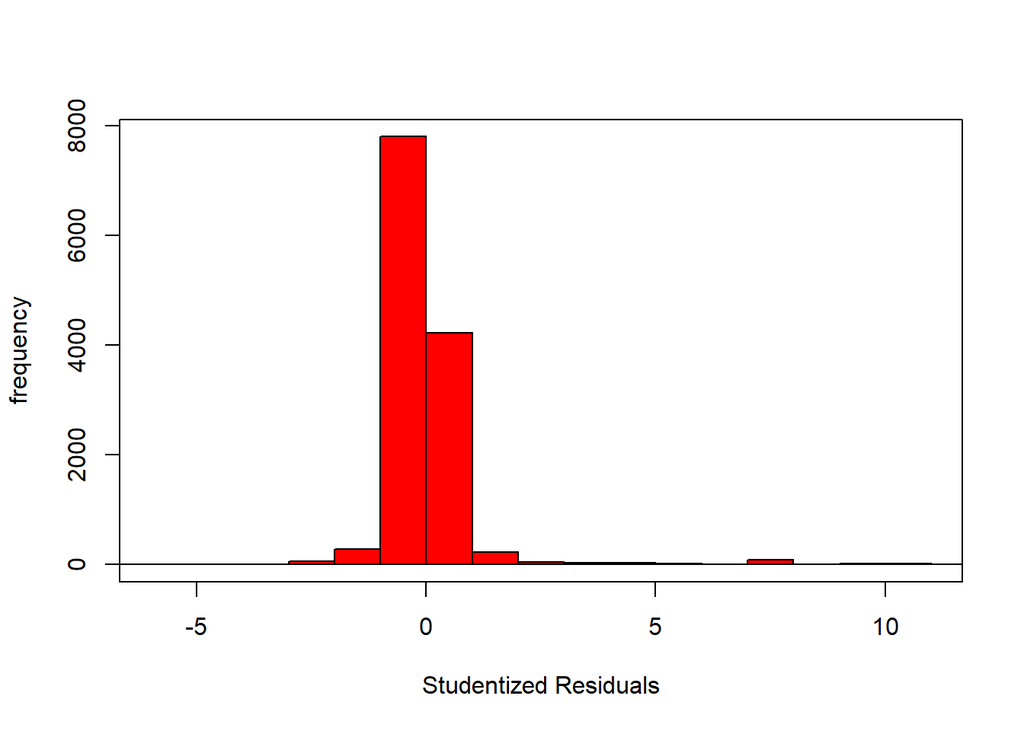

```r
with(Out_L_week_7_housing_updated, Hist(standardized.residuals, scale="frequency", breaks="Sturges", col="red",
  xlab="Studentized Residuals"))
```

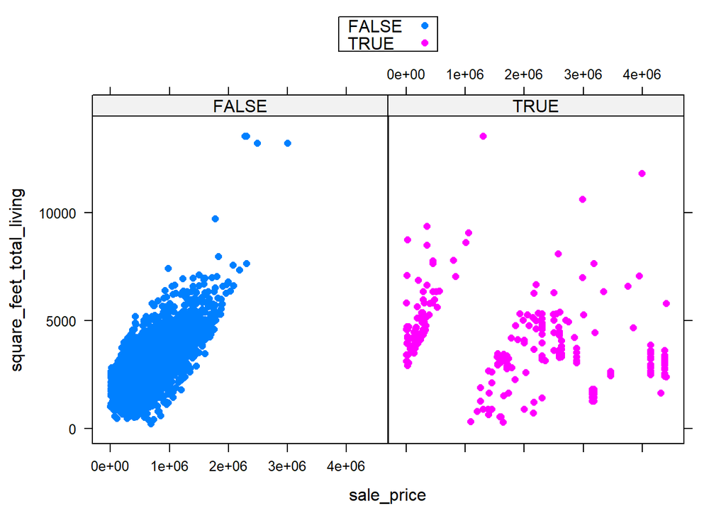

```r
library(lattice, pos = 24)
xyplot(square_feet_total_living ~ sale_price | large.residual, groups = large.residual, type = "p", pch = 16,
  auto.key = list(border = TRUE), par.settings = simpleTheme(pch = 16), scales = list(x = list(relation = 'same'),
  y = list(relation = 'same')), data = Out_L_week_7_housing_updated)
```

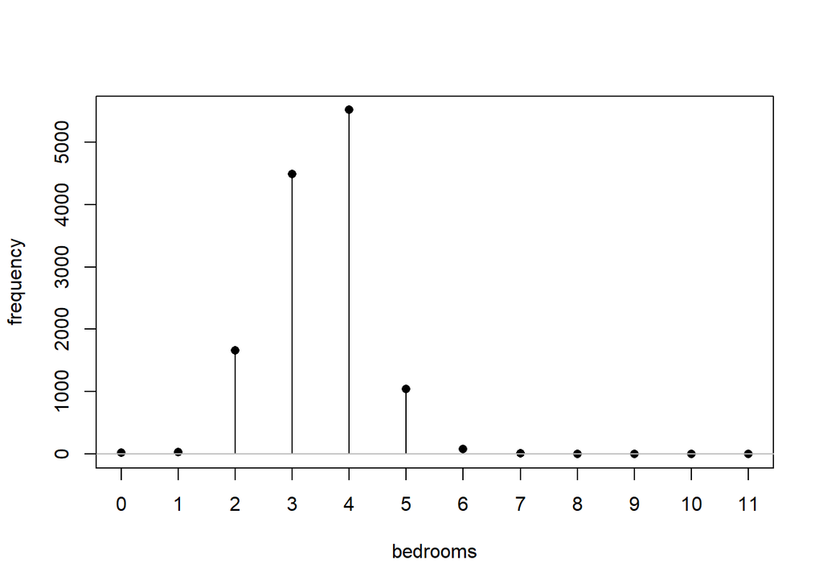

```r
with(Out_L_week_7_housing_updated, discretePlot(bedrooms,  scale = "frequency"))
```

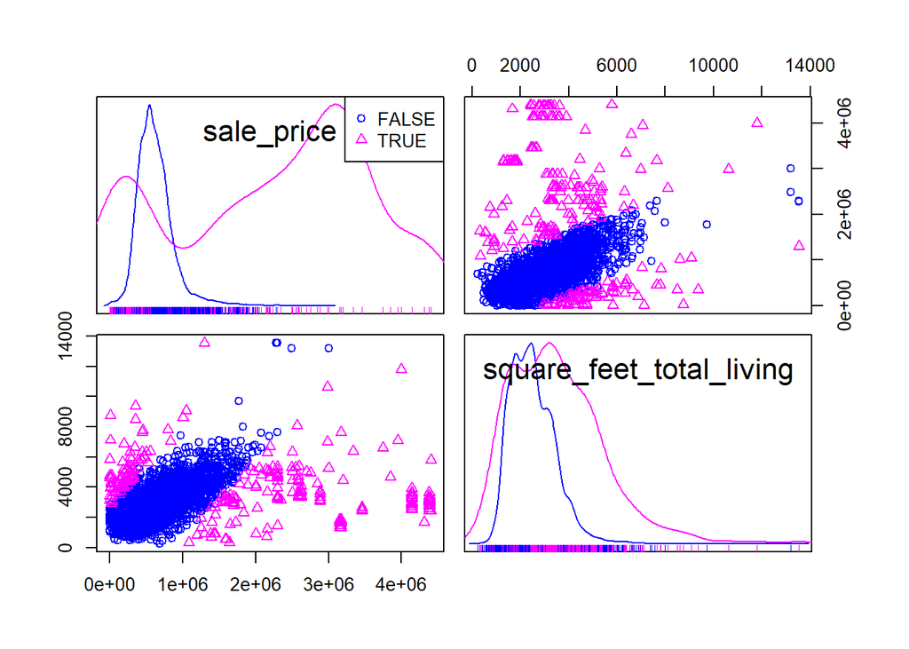

```r
scatterplotMatrix(~sale_price+square_feet_total_living | large.residual,
                       regLine = FALSE, smooth = FALSE, diagonal = list(method = "density"), by.groups = TRUE,
  data = Out_L_week_7_housing_updated)
```